# SARIMA Intervensi

```r
#install packages
library(forecast) # --- BoxCox Arima auto . arima function is in forecast
library(MASS) # --- boxcox function is in MASS package # --- LjungBoxTest function is in FitAR package
library(tsoutliers) # --- tso function is in tsoutliers package
library(lmtest) # --- coeftest function is in lmtest package
library(stargazer) # --- stargazer function is in stargazer package
library(TSA) # --- arimax function is in TSA package
```

```r
library(ggplot2)
library(astsa)
library(fUnitRoots)
library(strucchange)
library(reshape)
library(Rmisc)
library(fBasics)
library(tseries)
library(car)
library(nortest)
library(portes)
library(portes)
library(FinTS)
```

### Input data

```r
data <- read.csv("https://raw.githubusercontent.com/Raziqizzan03/MPDW/main/data/(Full%20Data)%20Data%20Pendatang%20Mancanegara%20di%20Provinsi%20Bali%20(1).csv")
data<-data[,2:3]
```

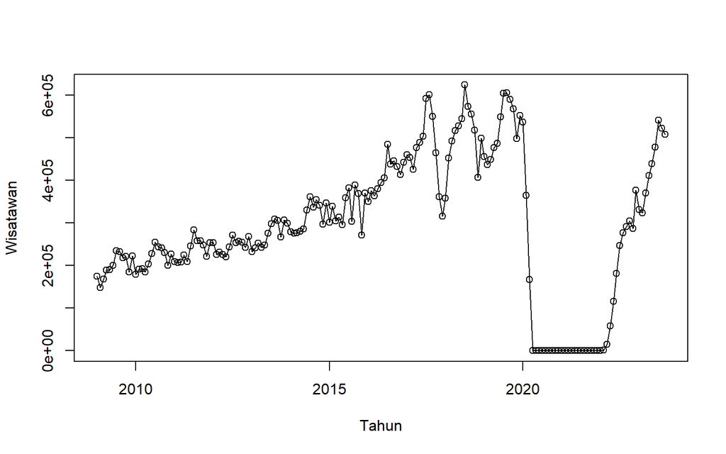

```r
plot_wisatawan = ts(data$Jumlah, frequency = 12, start= 2009)
plot(plot_wisatawan,
     xlab = "Tahun", ylab="Wisatawan")
points(plot_wisatawan)
```

### Pembagian data uji data tes

```r
training_data<-data[1:166,2]
ts_training<-ts(training_data,frequency=12)
testing_data<-data[167:177,2]
ts_testings<-ts(testing_data, frequency = 12)
```

### Pembagian data sebelum intervensi dan setelah intervensi

```r
data_sblm_intervensi<-ts(data[1:133,2], frequency = 12)
data_stlh_intervensi<-ts(data[134:166,2], frequency = 12)
```

# Uji kestasioneran data

### plot acf

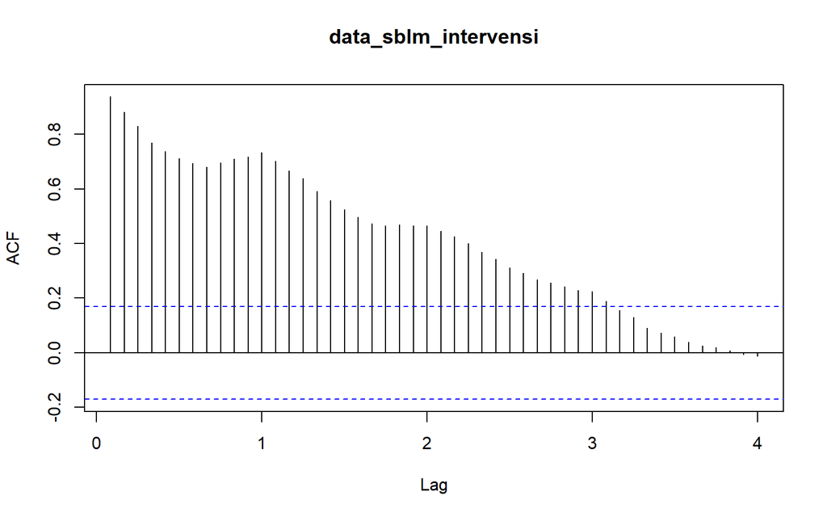

```r
Acf(data_sblm_intervensi, lag.max = 48)
```

Berdasarkan plot ACF, terlihat bahwa plot ACF pada data tersebut cenderung *tails off slowly*. menandakan bahwa data tersebut tidak stasioner dalam rataan

### Plot Box-Cox

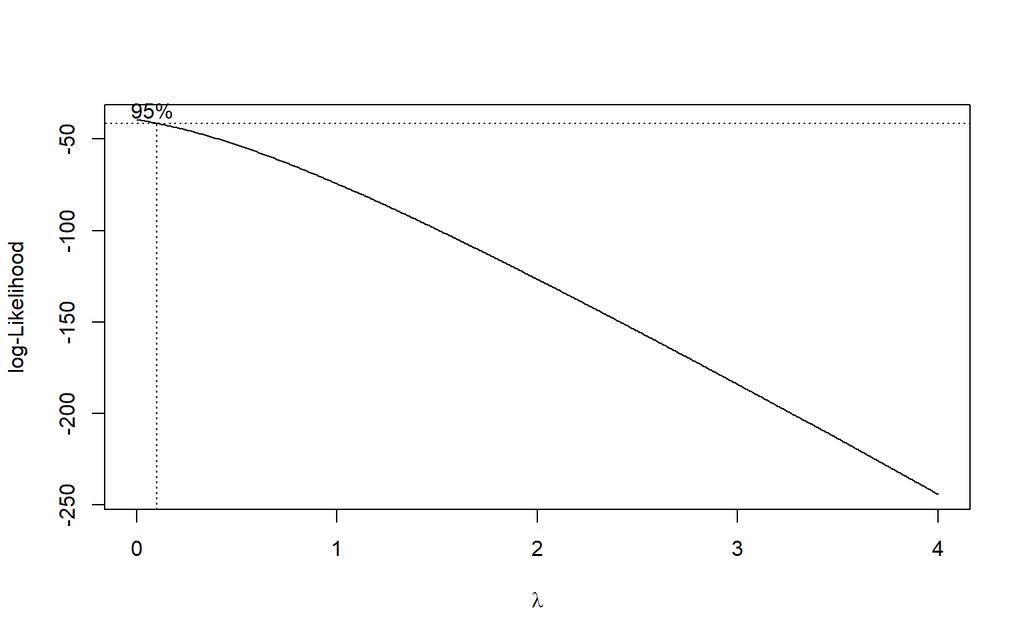

```r
index <- seq(1:133)
bc = boxcox(data_sblm_intervensi~index, lambda = seq(0,4,by=0.01))
```

```r
#Nilai Rounded Lambda
lambda <- bc$x[which.max(bc$y)]
lambda
```

```
## [1] 0
```

```r
#SK
bc$x[bc$y > max(bc$y) - 1/2 * qchisq(.95,1)]
```

```
##  [1] 0.00 0.01 0.02 0.03 0.04 0.05 0.06 0.07 0.08 0.09
```

Gambar di atas menunjukkan nilai *rounded value* ($\lambda$) optimum sebesar **0** dan pada selang kepercayaan 95% nilai memiliki batas bawah **0** dan batas atas **0.09**. Selang tersebut tidak memuat nilai satu sehingga dapat dikatakan bahwa data bangkitan tidak stasioner dalam ragam.

# Penanganan kestasioneran

### Transformasi logaritma

karena lamda yg didapatkan 0 maka dilakukan transformasi logaritma

```r
data_sblm_intervensi <- log(data_sblm_intervensi)
data_stlh_intervensi <- log(data_stlh_intervensi)
```

### Cek stasioner dalam ragam kembali

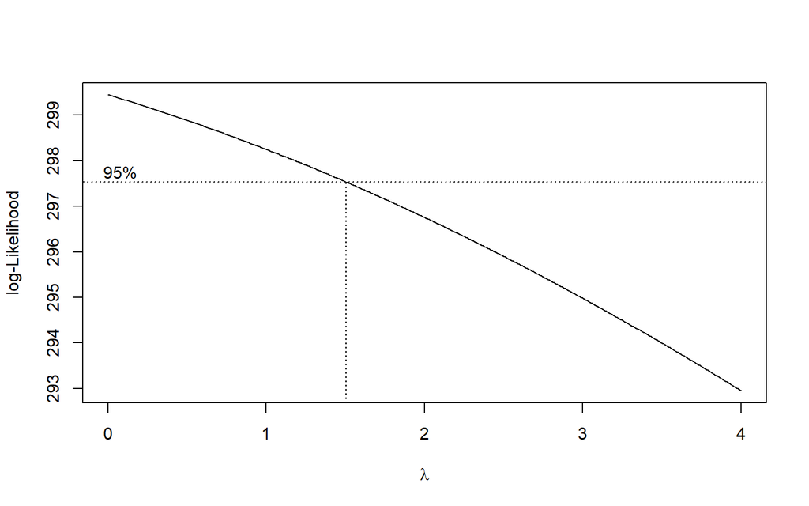

```r
index <- seq(1:133)
bc = boxcox(data_sblm_intervensi~index, lambda = seq(0,4,by=0.01))
```

```r
#Nilai Rounded Lambda
lambda <- bc$x[which.max(bc$y)]
lambda
```

```
## [1] 0
```

```r
#SK
bc$x[bc$y > max(bc$y) - 1/2 * qchisq(.95,1)]
```

```
##   [1] 0.00 0.01 0.02 0.03 0.04 0.05 0.06 0.07 0.08 0.09 0.10 0.11 0.12 0.13 0.14
##  [16] 0.15 0.16 0.17 0.18 0.19 0.20 0.21 0.22 0.23 0.24 0.25 0.26 0.27 0.28 0.29
##  [31] 0.30 0.31 0.32 0.33 0.34 0.35 0.36 0.37 0.38 0.39 0.40 0.41 0.42 0.43 0.44
##  [46] 0.45 0.46 0.47 0.48 0.49 0.50 0.51 0.52 0.53 0.54 0.55 0.56 0.57 0.58 0.59
##  [61] 0.60 0.61 0.62 0.63 0.64 0.65 0.66 0.67 0.68 0.69 0.70 0.71 0.72 0.73 0.74
##  [76] 0.75 0.76 0.77 0.78 0.79 0.80 0.81 0.82 0.83 0.84 0.85 0.86 0.87 0.88 0.89
##  [91] 0.90 0.91 0.92 0.93 0.94 0.95 0.96 0.97 0.98 0.99 1.00 1.01 1.02 1.03 1.04
## [106] 1.05 1.06 1.07 1.08 1.09 1.10 1.11 1.12 1.13 1.14 1.15 1.16 1.17 1.18 1.19
## [121] 1.20 1.21 1.22 1.23 1.24 1.25 1.26 1.27 1.28 1.29 1.30 1.31 1.32 1.33 1.34
## [136] 1.35 1.36 1.37 1.38 1.39 1.40 1.41 1.42 1.43 1.44 1.45 1.46 1.47 1.48 1.49
## [151] 1.50
```

### differensiasi pada non musimannya dan musimannya

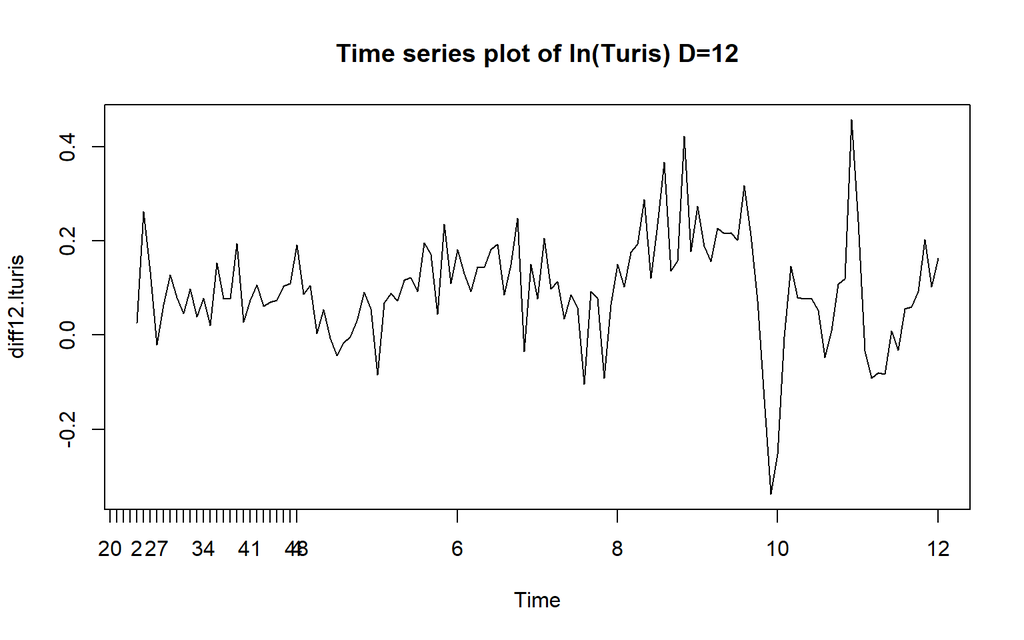

```r
diff12.lturis <- diff(data_sblm_intervensi,lag=12)
     plot(diff12.lturis, main = "Time series plot of ln(Turis) D=12")
     axis(1, at=0:48/12, labels=0:48)
```

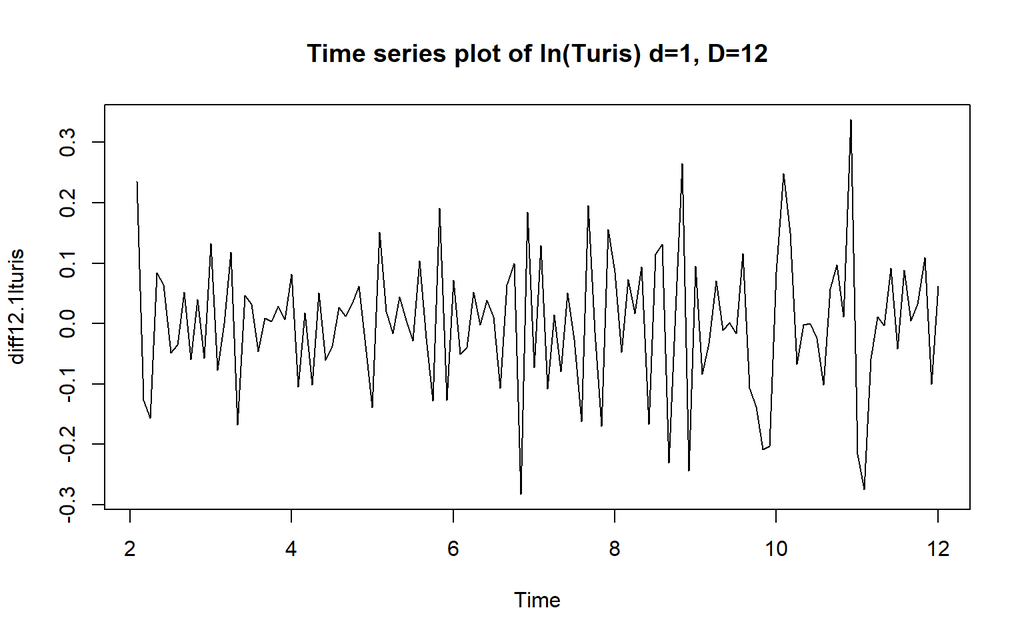

```r
diff12.1lturis <- diff(diff12.lturis,differencing=1)
     plot(diff12.1lturis, main = "Time series plot of ln(Turis) d=1, D=12")
```

## Cek kembali stasioner dalam rataan

### plot acf

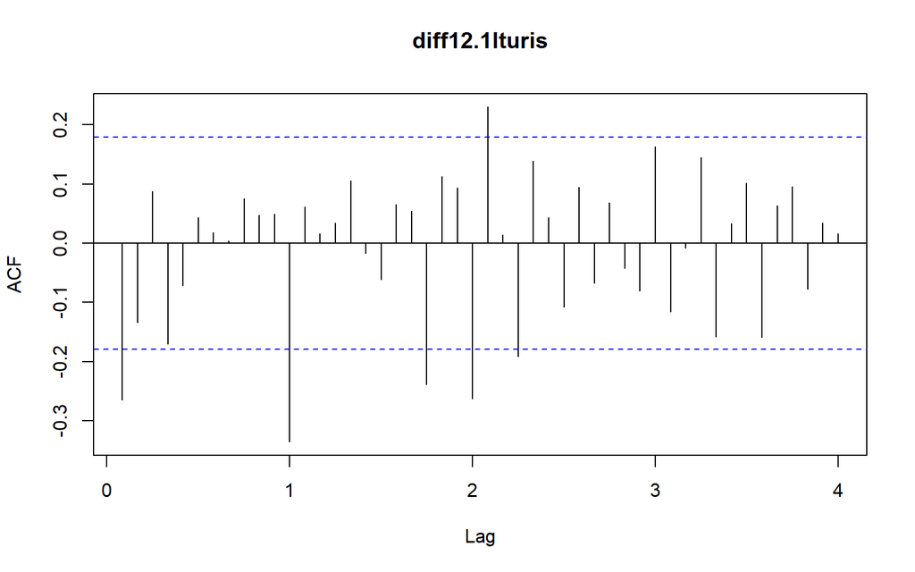

```r
Acf(diff12.1lturis, lag.max = 48)
```

sudah stasioner dalam ragam dan rataan

# Identifikasi model

### Plot acf dan pacf

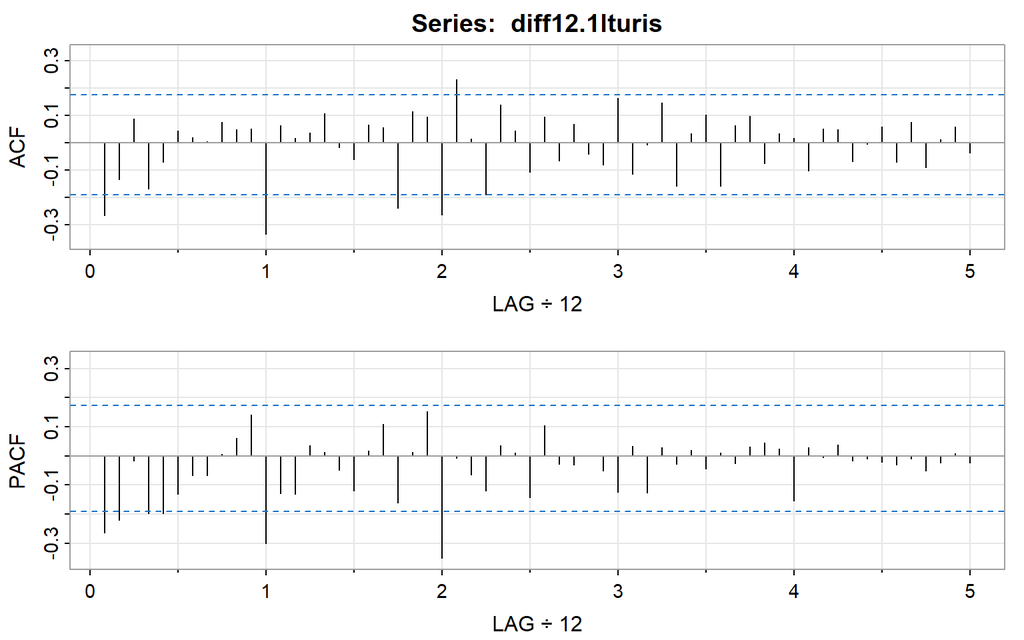

```
##       [,1]  [,2]  [,3]  [,4]  [,5]  [,6]  [,7]  [,8] [,9] [,10] [,11] [,12]
## ACF  -0.27 -0.13  0.09 -0.17 -0.07  0.04  0.02  0.00 0.08  0.05  0.05 -0.34
## PACF -0.27 -0.22 -0.02 -0.20 -0.20 -0.13 -0.07 -0.07 0.01  0.06  0.14 -0.30
##      [,13] [,14] [,15] [,16] [,17] [,18] [,19] [,20] [,21] [,22] [,23] [,24]
## ACF   0.06  0.02  0.03  0.11 -0.02 -0.06  0.07  0.05 -0.24  0.11  0.09 -0.26
## PACF -0.13 -0.13  0.04  0.01 -0.05 -0.12  0.02  0.11 -0.16  0.01  0.15 -0.35
##      [,25] [,26] [,27] [,28] [,29] [,30] [,31] [,32] [,33] [,34] [,35] [,36]
## ACF   0.23  0.01 -0.19  0.14  0.04 -0.11  0.09 -0.07  0.07 -0.04 -0.08  0.16
## PACF -0.01 -0.07 -0.12  0.04  0.01 -0.14  0.10 -0.03 -0.03  0.00 -0.05 -0.12
##      [,37] [,38] [,39] [,40] [,41] [,42] [,43] [,44] [,45] [,46] [,47] [,48]
## ACF  -0.12 -0.01  0.15 -0.16  0.03  0.10 -0.16  0.06  0.10 -0.08  0.03  0.02
## PACF  0.03 -0.13  0.03 -0.03  0.02 -0.04  0.01 -0.03  0.03  0.05  0.03 -0.15
##      [,49] [,50] [,51] [,52] [,53] [,54] [,55] [,56] [,57] [,58] [,59] [,60]
## ACF  -0.10  0.05  0.05 -0.07 -0.01  0.06 -0.07  0.07 -0.09  0.01  0.06 -0.04
## PACF  0.03 -0.01  0.04 -0.02 -0.01 -0.02 -0.03 -0.01 -0.05 -0.02  0.01 -0.02
```

```r
acf2(diff12.1lturis,60)
```

dapat dilihat pada plot acf model yg terbentuk ialah $ARIMA(0,1,1)×ARIMA(0,1,2)_{12}$ dapat dilihat pada plot pacf model yg terbentuk ialah $ARIMA(2,1,0)×ARIMA(2,1,0)_{12}$

selain itu terdapat model lain yg terbentuk dari persilangan dan penggabungan yaitu $ARIMA(0,1,1)×ARIMA(2,1,0)_{12}$, $ARIMA(2,1,1)×ARIMA(0,1,2)_{12}$, $ARIMA(2,1,0)×ARIMA(0,1,2)_{12}$, $ARIMA(0,1,1)×ARIMA(2,1,2)_{12}$, dan $ARIMA(2,1,0)×ARIMA(2,1,2)_{12}$ $ARIMA(0,1,2)×ARIMA(2,1,0)_{12}$,dan $ARIMA(1,1,2)×ARIMA(2,1,0)_{12}$